# Metrics to measure sample diversity within metaprograms

Ally Hawkins

2026-02-17

In this notebook, I’m going to explore some metrics for measuring sample representation within metaprograms. The spectra that make up the metaprograms should come from a variety of samples and be evenly distributed across the contributing samples.

```r
library(ggplot2)

# Set default ggplot theme
theme_set(
  theme_bw()
)
```

## Set Up

```r
# metaprograms results directory
results_dir <- here::here("ews-nf-out", "metaprograms")

# params we are looking at in this particular notebook
# use these to construct the file paths
n_metaprograms <- seq(6, 15, 1)

# directories with metaprogram results
# one directory per n_metaprogram
metaprogram_output_dirs <- file.path(
  results_dir,
  glue::glue("metaprograms-{n_metaprograms}_cnmf-5-10-15_filtered")
)

# path to files with each of the metrics
metaprogram_files <- file.path(metaprogram_output_dirs, "metaprograms.rds") |>
  purrr::set_names(sprintf("k_%02d", n_metaprograms))
```

## Functions

```r
# read in the metaprogram object
# create a dataframe with metaprogram, spectra, and sample id
mp_clusters_to_df <- function(metaprogram_file){
  mp_object <- readr::read_rds(metaprogram_file)

  # pull out the cluster list which contains vectors of spectra for each metaprogram/cluster
  mp_df <- mp_object$cluster_list |>
    purrr::imap(\(spectra_list, mp_name) {
      tibble::tibble(
        metaprogram = mp_name,
        spectra = spectra_list
      )
    }) |>
    # turn into a single dataframe and add a column for sample id
    # extract from the spectra name
    purrr::list_rbind() |>
    dplyr::mutate(
      sample_id = stringr::str_extract(spectra, "SCPCS[0-9]{6}")
    )

  return(mp_df)
}
```

```r
# helper function for calculating entropy
entropy <- function(sample_n){
  sample_freq <- sample_n / sum(sample_n)
  -sum(sample_freq * log(sample_freq))
}

# calculate stats for all metaprograms
# returns a dataframe with metaprogram, total_spectra_per_mp, total_samples_per_mp
# proportion_of_total_samples, sample_frequency, shannon_entropy
# shannon_entropy_norm, eff_number, eff_number_norm
calculate_sample_stats <- function(mp_clusters_df){

  # how many total possible samples do we have
  total_samples <- length(unique(mp_clusters_df$sample_id))

  # df with one row per mp
  # calculates total spectra, entropy, norm entropy, eff species size
  mp_entropy_df <- mp_clusters_df |>
    dplyr::group_by(metaprogram, sample_id) |>
    dplyr::summarize(num_spectra_per_sample = dplyr::n(), .groups = "drop_last") |>  # total spectra per sample in a given mp |>
    # use reframe because we calculate multiple rows per group
    # avoids warning messages from summarize
    dplyr::summarize(
      total_spectra_per_mp = sum(num_spectra_per_sample),
      total_samples_per_mp = length(sample_id),
      proportion_of_total_samples = total_samples_per_mp/total_samples,
      shannon_entropy = entropy(num_spectra_per_sample), # entropy
      shannon_entropy_norm = shannon_entropy / log(total_samples_per_mp),# normalize by total possible samples in that mp
      eff_number = exp(shannon_entropy), # effective species size or Hill number order of 1
      eff_number_norm = eff_number/total_samples_per_mp # eff number should be close to the total possible samples in that mp
    )

  return(mp_entropy_df)

}
```

## Sample diversity metrics

First let’s read in the metaprogram objects for each value of k and create a data frame with `n_metaprograms`, `metaprogram`, `spectra`, and `sample_id`. Then we’ll calculate some statistics on each metaprogram. This will be present in a data frame with one row per n_metaprograms/ metaprogram and columns with associated stats.

We’ll look at a few metrics here to help evaulate the diversity of metaprograms:

- Total proportion of samples: The proportion of total samples that are represented in the metaprogram.
- Normalized Shannon’s diversity index or entropy: This measures the relative abundance of the samples in a metaprogram. This value is then normalized by the total number of samples in the metaprogram. Values close to 1 indicate samples contribute the metaprogram equally.
- Normalized effective species size or Hill number of order 1: The exponential of Shannon’s entropy representing the effective number of common or abundant species. Here we are looking for a number close to the total possible samples in that metaprogram. The values are normalized by the total number of samples in the metaprogram such that values close to 1 indicate all samples are equally abundant.

```r
# create a single dataframe with n_metaprograms, metaprogram, total spectra per mp, and diversity stats
mp_clusters_df_list <- metaprogram_files |>
  purrr::map(mp_clusters_to_df)

mp_entropy_df <- mp_clusters_df_list |>
  purrr::map(calculate_sample_stats) |>
  dplyr::bind_rows(.id = "n_metaprograms")
```

We’ll look at the distribution of the stats that are calculated for each metaprogram.

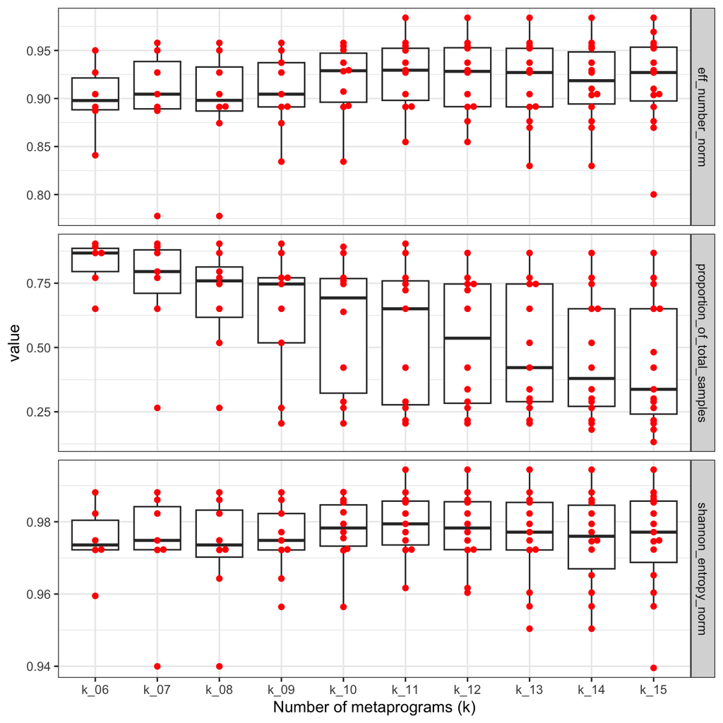

```r
stat_columns <- c(
  "proportion_of_total_samples",
  "shannon_entropy_norm",
  "eff_number_norm"
)

stats_plot_df <- mp_entropy_df |>
  tidyr::pivot_longer(cols = stat_columns,
                      names_to = "statistic",
                      values_to = "value")

ggplot(stats_plot_df, aes(x = n_metaprograms, y = value)) +
  geom_boxplot(outlier.shape = NA) +
  ggbeeswarm::geom_beeswarm(color = "red") +
  facet_grid(rows = vars(statistic),
             scales = "free") +
  labs(
    x = "Number of metaprograms (k)"
  )
```

```r
mp_entropy_df |>
  dplyr::group_by(n_metaprograms) |>
  dplyr::summarize(
    median_proportion = median(proportion_of_total_samples),
    median_entropy_norm = median(shannon_entropy_norm),
    median_eff_norm = mean(eff_number_norm),
    combined_median = median_entropy_norm + median_eff_norm + median_proportion
  ) |>
  DT::datatable()
```

|  | n_metaprograms | median_proportion | median_entropy_norm | median_eff_norm | combined_median |
| --- | --- | --- | --- | --- | --- |
| 1 | k_06 | 0.8674698795180723 | 0.9735740982166928 | 0.9001460819426405 | 2.741190059677406 |
| 2 | k_07 | 0.7951807228915663 | 0.9748401203594033 | 0.8993550834708596 | 2.669375926721829 |
| 3 | k_08 | 0.7590361445783133 | 0.9735740982166928 | 0.8967652442055184 | 2.629375487000524 |
| 4 | k_09 | 0.7469879518072289 | 0.9748401203594033 | 0.9075559716736825 | 2.629384043840314 |
| 5 | k_10 | 0.6927710843373494 | 0.978271919062782 | 0.9182992091239786 | 2.58934221252411 |
| 6 | k_11 | 0.6506024096385542 | 0.9794190055380164 | 0.9256511818243294 | 2.5556725970009 |
| 7 | k_12 | 0.536144578313253 | 0.978271919062782 | 0.921720483331116 | 2.436136980707151 |
| 8 | k_13 | 0.4216867469879518 | 0.9771248325875475 | 0.9157930897768273 | 2.314604669352327 |
| 9 | k_14 | 0.3795180722891566 | 0.9759824764734754 | 0.9162408259637899 | 2.271741374726422 |
| 10 | k_15 | 0.3373493975903614 | 0.9771248325875475 | 0.9177981153335516 | 2.23227234551146 |

- If you rank each of these individually, the proportion of samples seems to decrease as k increases. In contrast, the entropy and effective size seem to be more useful and not dependent on the value of k.
- One approach would be to just choose a lenient cutoff for minimum proportion and minimum entropy and/or effective size for a “good” MP.
- Alternatively, we could order the median values for normalized effective sample size and/or normalized entropy to get a rank and find the best k for this specific metric. It looks like ordering by either of these give the same results of k=11 and k=12 being the best values of k.
- Another idea I have is to use permutation testing to show that the observed entropy and effective size is greater than what is observed by chance. I will explore that in the next section.

## Permutation testing

In order to define a cutoff or possible range of what a “good” metaprogram is in regards to these stats, like shannon’s entropy and/or effective sample size, I thought it could be helpful to show that the number is greater than what you would expect by random chance with the given metaprograms. So here I am shuffling the spectra assigned to each metaprogram while preserving the number of spectra assigned to each metaprogram. I then recalculate the statistics creating a null distribution. I then compare the observed value to the null distribution to get an empirical pvalue. This produces a single pvalue for each metaprogram within a value of k for each stat. We can then count how many metaprograms have a significant pvalue for that k.

```r
# function to randomly shuffle spectra assignments and recalculate metrics
permute_stats <- function(mp_df, n_reps){

  # for each rep, shuffle the spectra
  # keep the distribution of num spectra/ mp the same
  background <- purrr::map(1:n_reps, \(n) {
    dplyr::mutate(mp_df, metaprogram = sample(metaprogram)) |>
      calculate_sample_stats()
  }) |>
    dplyr::bind_rows(.id = "rep_n")

  return(background)
}
```

```r
# define the number of reps for permutation
num_reps <- 50

stat_columns <- c("shannon_entropy_norm", "eff_number_norm")

# get a dataframe of all background points
# do permutation on each value of k separately
background_df <- mp_clusters_df_list |>
  purrr::map(permute_stats, n_reps = num_reps) |>
  dplyr::bind_rows(.id = "n_metaprograms") |>
  dplyr::select(-rep_n) |>
  # pivot to have one column with all stats
  tidyr::pivot_longer(
    cols = stat_columns,
    values_to = "background_value",
    names_to = "statistic"
  ) |>
  dplyr::select(n_metaprograms, metaprogram, statistic, background_value)

# assign a pvalue for each metaprogram for each value of k using the background
p_value_df <- mp_entropy_df |>
  # create a single obs value column for the stats we want to calculate pvalues for
  tidyr::pivot_longer(
    cols = stat_columns,
    values_to = "obs_value",
    names_to = "statistic"
  ) |>
  # join with background data points
  dplyr::left_join(background_df, by = c("n_metaprograms", "metaprogram", "statistic")) |>
  dplyr::mutate(
    # boolean column indicating if the background value is > observed
    greater_than_obs = background_value > obs_value
  ) |>
  dplyr::group_by(n_metaprograms, metaprogram, total_spectra_per_mp, statistic) |>
  # calculate empirical pvalue for each metaprogram
  dplyr::summarize(
    obs_value = unique(obs_value), # retain this value for including it in the plot
    p_value = (sum(greater_than_obs)+1)/(num_reps + 1)
  ) |>
  # add adjusted pvalues and significance
  dplyr::mutate(
    adj_pvalue = p.adjust(p_value, method = "BH"),
    significance = dplyr::if_else(adj_pvalue <= 0.05, "sig", "ns")
  )
```

Below we will look at the results. Each row is a metaprogram for a given value of k. We will show the total spectra per metaprogam alongside each of the adjusted pvalues for a given statistic.

```r
p_value_df |>
  dplyr::select(-c("p_value", "significance")) |>
  tidyr::pivot_wider(
    names_from = "statistic",
    values_from = c("obs_value", "adj_pvalue")
  ) |>
  DT::datatable(options = list(scrollX = TRUE))
```

|  | n_metaprograms | metaprogram | total_spectra_per_mp | obs_value_eff_number_norm | obs_value_shannon_entropy_norm | adj_pvalue_eff_number_norm | adj_pvalue_shannon_entropy_norm |
| --- | --- | --- | --- | --- | --- | --- | --- |
| 1 | k_06 | MP01 | 230 | 0.9500214304848138 | 0.9881248691626563 | 0.0196078431372549 | 0.0196078431372549 |
| 2 | k_06 | MP02 | 123 | 0.904509601903649 | 0.9748401203594033 | 0.05882352941176471 | 0.05882352941176471 |
| 3 | k_06 | MP03 | 410 | 0.8409014116671197 | 0.9594822582439204 | 1 | 1 |
| 4 | k_06 | MP04 | 248 | 0.8912168757870876 | 0.9723080760739824 | 0.196078431372549 | 0.196078431372549 |
| 5 | k_06 | MP05 | 233 | 0.9269992666307982 | 0.9822753279241091 | 0.0196078431372549 | 0.0196078431372549 |
| 6 | k_06 | MP06 | 365 | 0.8872279051823742 | 0.9721999115351441 | 0.392156862745098 | 0.392156862745098 |
| 7 | k_07 | MP01 | 230 | 0.9500214304848138 | 0.9881248691626563 | 0.0196078431372549 | 0.0196078431372549 |
| 8 | k_07 | MP02 | 123 | 0.904509601903649 | 0.9748401203594033 | 0.05882352941176471 | 0.05882352941176471 |
| 9 | k_07 | MP03 | 303 | 0.7776465479896166 | 0.9399752051148449 | 1 | 1 |
| 10 | k_07 | MP04 | 248 | 0.8912168757870876 | 0.9723080760739824 | 0.0392156862745098 | 0.0392156862745098 |

[output cut: 95 more lines]

Below we will plot the observed values in relation to the background distribution for each metaprogram for each value of k. The sina plot corresponds to the background and the diamond indicate the observed values for each metaprogram. Red diamonds indicate that the adjusted pvalue is <= 0.05. One plot is shown for each statistic.

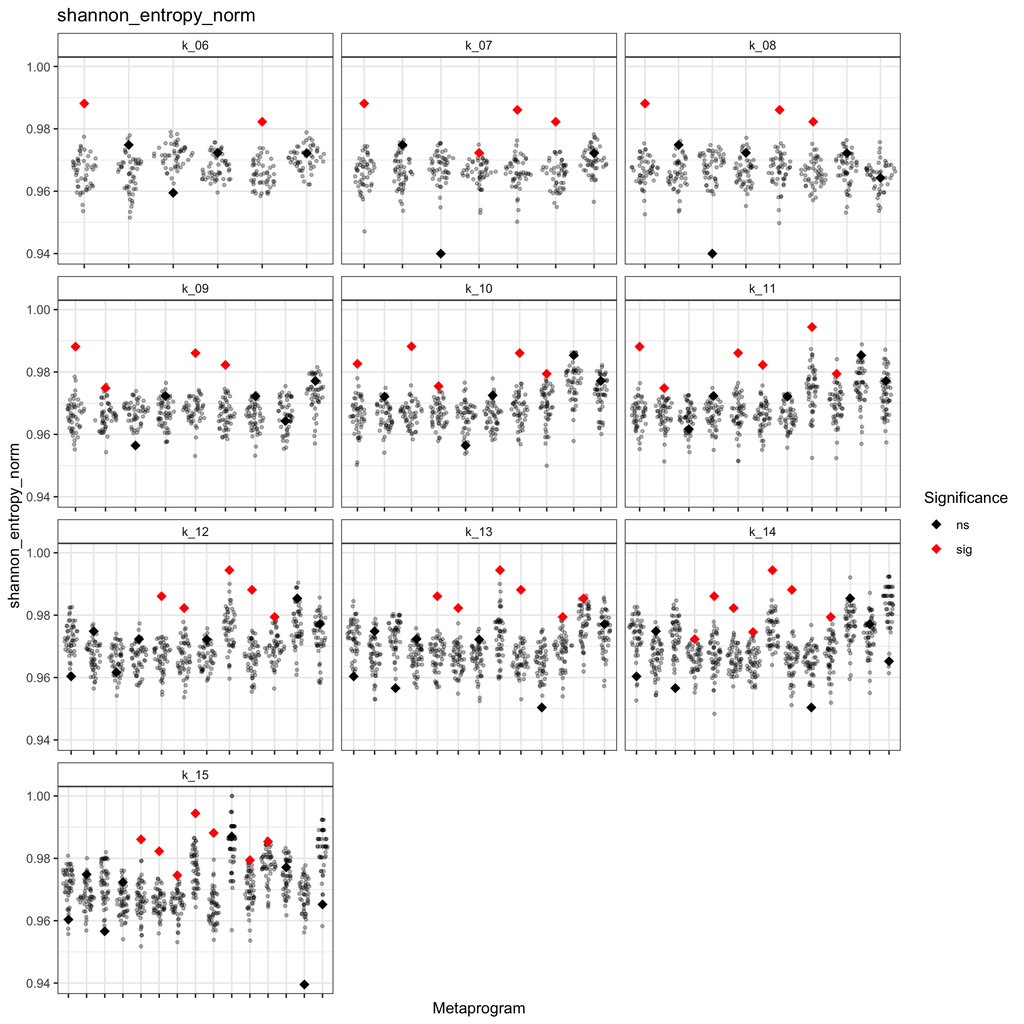

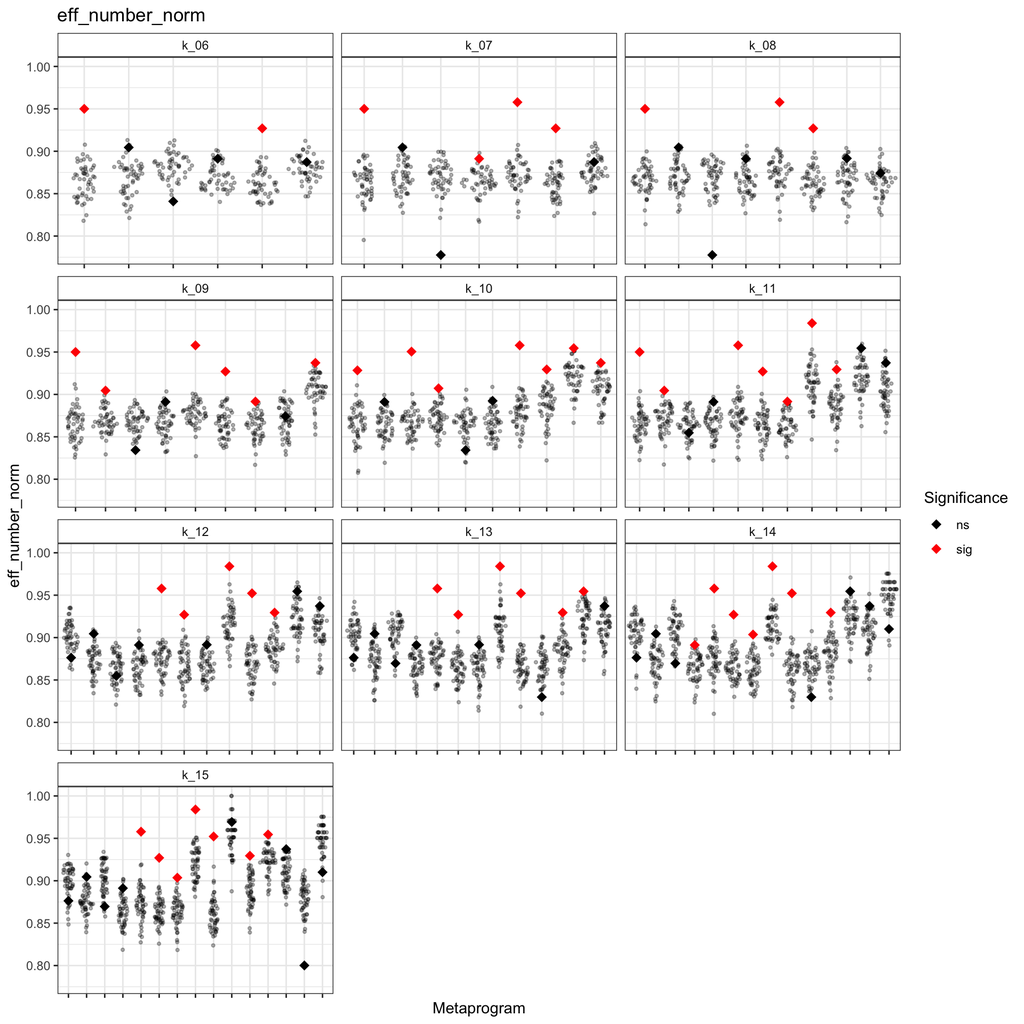

```r
plots <- purrr::map(stat_columns, \(stat) {

    bg  <- background_df |> dplyr::filter(statistic == stat)
    obs <- p_value_df |> dplyr::filter(statistic == stat)

    ggplot(bg, aes(x = metaprogram, y = background_value)) +
      ggforce::geom_sina(
        color = "black",
        alpha = 0.3,
        size  = 0.8
      ) +
      geom_point(
        data = obs,
        aes(
          x = metaprogram,
          y = obs_value,
          color = significance
        ),
        size  = 3,
        shape = 18  # diamond
      ) +
      facet_wrap(
        vars(n_metaprograms),
        scales = "free_x",
        ncol = 3
      ) +
        scale_color_manual(
          values = c("sig" = "red", "ns" = "black")
        ) +
        labs(
          x = "Metaprogram",
          y = stat,
          color = "Significance",
          title = stat
        ) +
      theme(
        strip.background = element_rect(fill = "transparent"),
        axis.text.x = element_blank(),
      )
})

purrr::walk(plots, print)
```

It looks like around half of the metaprograms have a significant p-value and are greater than the null distribution. This looks like it might be promising to consider? I don’t know that we want to throw out metaprograms on this metric alone, but we could count the number of significant metaprograms per k to get an “optimal” k, at least for this metric. Also, the results look very similar to each other, which makes sense since effective sample size is calculated from entropy. We probably only need to use one of these metrics moving forward.

```r
# how many MPs are significant per value of k?
p_value_df |>
  dplyr::group_by(n_metaprograms, statistic) |>
  dplyr::summarise(
    total_programs = length(metaprogram),
    sig_programs = sum(significance == "sig"),
    proportion_sig = sig_programs/total_programs
  ) |>
  dplyr::arrange(desc(proportion_sig)) |>
  DT::datatable()
```

|  | n_metaprograms | statistic | total_programs | sig_programs | proportion_sig |
| --- | --- | --- | --- | --- | --- |
| 1 | k_10 | eff_number_norm | 10 | 7 | 0.7 |
| 2 | k_09 | eff_number_norm | 9 | 6 | 0.6666666666666666 |
| 3 | k_11 | eff_number_norm | 11 | 7 | 0.6363636363636364 |
| 4 | k_07 | eff_number_norm | 7 | 4 | 0.5714285714285714 |
| 5 | k_07 | shannon_entropy_norm | 7 | 4 | 0.5714285714285714 |
| 6 | k_11 | shannon_entropy_norm | 11 | 6 | 0.5454545454545454 |
| 7 | k_10 | shannon_entropy_norm | 10 | 5 | 0.5 |
| 8 | k_14 | eff_number_norm | 14 | 7 | 0.5 |
| 9 | k_14 | shannon_entropy_norm | 14 | 7 | 0.5 |
| 10 | k_15 | eff_number_norm | 15 | 7 | 0.4666666666666667 |

[output cut: 10 more lines]

If we rank the values based on the proportion of significant metaprograms, we see that k=10 has the most. Note that if we just used the median of the effective sample size, k=11 and k=12 had the highest values.

## Conclusions

If I were thinking about a strategy to define usable MPs, I might consider both the proportion of samples and effective sample size together. That could look like:

- Implementing a minimum sample proportion, effective sample size and/or entropy.
- Counting the proportion of metaprograms that have a significant effective sample size.